# POLS 2972Q

Quantitative Analysis in Political Science

Lecture 21 |

Quantifying Uncertainty

## Plan for Today

- In-class activity
  - Hypothesis testing with the STAR data
  - Internal and external validity

## Class Activity

- Get with a partner
- Open RStudio
- Download the data: STAR Data

## Do Small Classes Increase the Probability of Graduating High School?

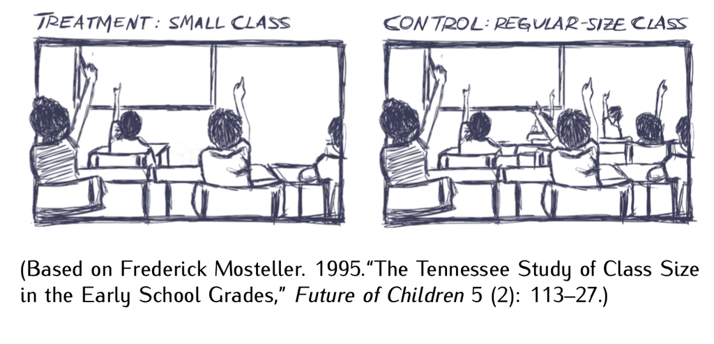

- The data come from a randomized experiment conducted in Tennessee, where students were randomly assigned to attend either a small class or a regular-size class from kindergarten until 3rd grade

## Load the Data

- Put `STAR.csv` in the same folder as your script, then load it and look at the last few rows

```r
star <- read.csv("STAR.csv")

tail(star)
```

```
     classtype reading math graduated
1269     small     657  603         1
1270   regular     650  663         1
1271     small     636  618         1
1272     small     629  631         1
1273   regular     641  651         0
1274     small     575  576         1
```

## Three Questions Before We Model

- What is the treatment variable?
- What is the outcome variable?
- Is the outcome variable binary? How does this affect the interpretation of $\hat{\beta}$?
- Treatment variable: `classtype`, whether the student was assigned to a small class
- Outcome variable: `graduated`, whether the student graduated from high school
- Yes, `graduated` is binary
  - When Y is binary, its mean is a proportion
  - So $\hat{\beta}$ is a difference between two proportions, which we read in percentage points

## Create the Treatment Variable

- Use `classtype` to build a 0/1 indicator for assignment to a small class

```r
star <- star |>
  mutate(small = ifelse(classtype == "small", 1, 0))
```

## Fit the Model

- Fit a linear model so that the estimated slope coefficient equals the difference-in-means estimator

```r
fit <- lm(graduated ~ small, data = star)

summary(fit)
```

```
Call:
lm(formula = graduated ~ small, data = star)

Residuals:
    Min      1Q  Median      3Q     Max
-0.8735  0.1265  0.1265  0.1335  0.1335

Coefficients:
            Estimate Std. Error t value Pr(>|t|)
(Intercept) 0.866473   0.012834  67.514   <2e-16 ***
small       0.007031   0.018940   0.371    0.711
---
Signif. codes:  0 '***' 0.001 '**' 0.01 '*' 0.05 '.' 0.1 ' ' 1

Residual standard error: 0.3369 on 1272 degrees of freedom
Multiple R-squared:  0.0001083, Adjusted R-squared:  -0.0006777
F-statistic: 0.1378 on 1 and 1272 DF,  p-value: 0.7105
```

## What Is $\hat{\beta}$?

- Find the estimated slope coefficient on `small`
- $\hat{\beta}$ = 0.007
- This is the same number we would get by subtracting the two group proportions directly

```r
mean(star$graduated[star$small == 1]) - mean(star$graduated[star$small == 0])
```

```
[1] 0.007031124
```

## Direction, Size, and Unit of Measurement

- What is the direction of the effect?
- What is the size of the effect?
- What is the unit of measurement?
- An increase of about 0.7 percentage points
- Increase, because we are measuring a change in Y and $\hat{\beta}$ is positive
- Percentage points, because the difference-in-means estimator subtracts two percentages: % - % = p.p. (because `graduated` is binary)
- 0.7 rather than 0.007, because we multiply by 100 to convert to percentage points

## What Is the Estimated Average Treatment Effect?

- State the effect in a sentence you could put in a paper
- Students who attended a small class were comparable to students who attended a regular-size class, which is a reasonable assumption because the data come from a randomized experiment
- We estimate that attending a small class increases the probability of graduating from high school by about 0.7 percentage points, on average

## Is the Effect Statistically Significant?

- That is, can we distinguish the average treatment effect from zero at the population level?
- Specify the null and alternative hypotheses
- $H_0: B = 0$
  - Attending a small class has no average causal effect on the probability of graduating from high school at the population level
- $H_1: B \neq 0$
  - Attending a small class either increases or decreases the probability of graduating from high school, on average, at the population level

## Compute the Test Statistic and P-Value

```r
summary(fit)$coef
```

```
               Estimate Std. Error    t value  Pr(>|t|)
(Intercept) 0.866473149 0.01283401 67.5138061 0.0000000
small       0.007031124 0.01893953  0.3712406 0.7105202
```

- What is the observed test statistic?
- What is the observed p-value?
- Do we reject or fail to reject the null hypothesis?
- $Z^{obs}$ = 0.371
- p-value = 0.711
- We fail to reject the null hypothesis
  - $|Z^{obs}|$ = 0.371 < 1.96
  - p-value = 0.711 > 0.05

## Is the Effect Statistically Significant at the 5% Level?

- No, the effect is not statistically significant at the 5% level
- The data do not give us enough evidence to distinguish the average causal effect from zero at the population level
- Careful with the wording here
  - Failing to reject $H_0$ is not evidence that the effect is zero
  - The confidence interval runs from about -0.030 to 0.044, so values well above zero remain consistent with these data
  - The honest statement is that this study cannot tell us the sign of the effect

## Can We Interpret the Effect as Causal?

- How strong is the internal validity of this study?
- Have the researchers accurately measured the average causal effect on the sample of students who were part of the study?
- Yes, we can interpret the effect as causal
- The internal validity of this study is strong because the treatment was assigned at random
- Random treatment assignment should have eliminated all confounding variables
  - Students assigned to attend a small class should be comparable to students assigned to attend a regular-size class

## Can We Generalize the Results?

- How strong is the external validity of this study?
- To what population can the findings be generalized?
- Only students from large schools in Tennessee were able to participate in the experiment
- The sample of participating students was not perfectly representative of all students in Tennessee or of all students in the United States
- We do get to observe the treatment of interest in the real world, but the analysis has relatively weak external validity
  - This matters most if we want to generalize to all schools and students in Tennessee or in the entire United States
  - See subsection 5.5.4 of the book

## For Next Class

- Review what you learned today
- Bring your laptops to class